# Projeto de Análise de Neoplasia da Bexiga

Christian Neitzel, Diana Silva, Diogo Esteves, Tiago Miranda

2024-05-29

## Introdução

**Contextualização**

A neoplasia da bexiga representa um desafio global de saúde, sendo uma das formas de cancro mais prevalentes em todo o mundo. Embora a abordagem clínica tenha permanecido largamente inalterada ao longo dos anos, descobertas recentes têm aberto caminho para uma nova era no diagnóstico e gestão da doença (Dyrskjøt et al., 2023). A mortalidade específica começou a diminuir em regiões com maior consciencialização social dos fatores de risco e redução da exposição a agentes carcinogénicos. A remoção cirurgica radical da bexiga continua a ser o padrão-ouro para casos invasivos, enquanto o valor clínico da linfadenectomia e alternativas à quimioterapia perioperatória estão a ser desafiados. Paralelamente, avanços na biologia molecular e na compreensão da tumorigénese estão a abrir caminho para uma medicina personalizada. A detecção precoce é crucial para um melhor prognóstico, e métodos minimamente invasivos de diagnóstico são essenciais (Dobruch & Oszczudłowski, 2021).

**Análise Demonstrativa de Expressão Genética Diferencial**

Este trabalho contém uma análise demonstrativa de expressão genética diferencial, utilizando amostras de sequenciamento direcionado presentes no estudo “Genomic Differences Between”Primary” and “Secondary” Muscle-invasive Bladder Cancer as a Basis for Disparate Outcomes to Cisplatin-based Neoadjuvant Chemotherapy” (https://www.cbioportal.org/study/summary?id=blca_msk_tcga_2020). Neste estudo os investigadores tiveram como objetivo, investigar as diferenças genômicas entre o carcinoma de bexiga músculo-invasivo “primário” e “secundário” e como estas diferenças afetam a resposta à quimioterapia neoadjuvante à base de cisplatina. Os autores analisaram dados genômicos de pacientes com carcinoma de bexiga músculo-invasivo tratados com quimioterapia neoadjuvante à base de cisplatina. Os pacientes foram divididos em dois grupos: aqueles com carcinoma de bexiga “primário” (sem tratamento prévio) e aqueles com carcinoma de bexiga “secundário” (já tratado com quimioterapia ou radiação).

## Fase 1: Exploração e Análise de Dados

A primeira fase compreenderá as seguintes etapas: explicação da origem e relevância dos dados; realização de tarefas de preparação e pré-processamento dos dados; resumo dos dados através de estatísticas descritivas e exploração visual por meio de gráficos; realização de análises estatísticas univariadas; e por fim, análise de expressão diferencial e de enriquecimento.

#### Instalação e importação de packages

# Exploração dos dados presentes no dataset

Nesta fase é realizado o carregamento dos dados clinicos do estudo, explorados os ensaios do estudo disponiveis e organizados em dataframes:

```r
## Inicialização do API cBioPortal e obtenção dos dados do estudo "blca_msk_tcga_2020"

# Automaticamente define a working directory para o local deste ficheiro .Rmd
setwd(dirname(rstudioapi::getSourceEditorContext()$path))

# Inicialização da API do cBioPortal
cbio <- cBioPortal()

# Obter dados clínicos
bladder_clin <- clinicalData(api = cbio, studyId = "blca_msk_tcga_2020")
dim(bladder_clin)  # Deve retornar 476 linhas e 42 colunas
```

```
## [1] 476  42
```

```r
# Carrega os dados do cBioPortal
bladder = cBioDataPack("blca_msk_tcga_2020", ask = FALSE)
```

```
## Study file in cache: blca_msk_tcga_2020
```

```
## Working on: C:\Users\dases\AppData\Local\Temp\Rtmpuacqdh/4374211c653a_blca_msk_tcga_2020/blca_msk_tcga_2020/data_cna.txt
```

```
## Working on: C:\Users\dases\AppData\Local\Temp\Rtmpuacqdh/4374211c653a_blca_msk_tcga_2020/blca_msk_tcga_2020/data_cna_hg19.seg
```

```
## Working on: C:\Users\dases\AppData\Local\Temp\Rtmpuacqdh/4374211c653a_blca_msk_tcga_2020/blca_msk_tcga_2020/data_gene_panel_matrix.txt
```

```
## Working on: C:\Users\dases\AppData\Local\Temp\Rtmpuacqdh/4374211c653a_blca_msk_tcga_2020/blca_msk_tcga_2020/data_log2_cna.txt
```

```
## Working on: C:\Users\dases\AppData\Local\Temp\Rtmpuacqdh/4374211c653a_blca_msk_tcga_2020/blca_msk_tcga_2020/data_mrna_seq_v2_rsem.txt
```

```
## Working on: C:\Users\dases\AppData\Local\Temp\Rtmpuacqdh/4374211c653a_blca_msk_tcga_2020/blca_msk_tcga_2020/data_mrna_seq_v2_rsem_zscores_ref_all_samples.txt
```

```
## Working on: C:\Users\dases\AppData\Local\Temp\Rtmpuacqdh/4374211c653a_blca_msk_tcga_2020/blca_msk_tcga_2020/data_mrna_seq_v2_rsem_zscores_ref_diploid_samples.txt
```

```
## Working on: C:\Users\dases\AppData\Local\Temp\Rtmpuacqdh/4374211c653a_blca_msk_tcga_2020/blca_msk_tcga_2020/data_mutations.txt
```

```
## Working on: C:\Users\dases\AppData\Local\Temp\Rtmpuacqdh/4374211c653a_blca_msk_tcga_2020/blca_msk_tcga_2020/data_rppa.txt
```

```
## Working on: C:\Users\dases\AppData\Local\Temp\Rtmpuacqdh/4374211c653a_blca_msk_tcga_2020/blca_msk_tcga_2020/data_rppa_zscores.txt
```

```
## Working on: C:\Users\dases\AppData\Local\Temp\Rtmpuacqdh/4374211c653a_blca_msk_tcga_2020/blca_msk_tcga_2020/data_sv.txt
```

```
## Working on: C:\Users\dases\AppData\Local\Temp\Rtmpuacqdh/4374211c653a_blca_msk_tcga_2020/blca_msk_tcga_2020/data_timeline.txt
```

```r
# Lista os nomes dos ensaios disponíveis no pacote dos dados do CBioPortal
names(assays(bladder))
```

```
## [1] "cna"
## [2] "cna_hg19.seg"
## [3] "log2_cna"
## [4] "mrna_seq_v2_rsem"
## [5] "mrna_seq_v2_rsem_zscores_ref_all_samples"
## [6] "mrna_seq_v2_rsem_zscores_ref_diploid_samples"
## [7] "mutations"
## [8] "rppa"
## [9] "rppa_zscores"
```

```r
names(colData(bladder)) # tipos de metadados associados a cada amostra
```

```
##  [1] "PATIENT_ID"                      "SAMPLE_ID"
##  [3] "ANALYSIS_COHORT"                 "PLATFORM"
##  [5] "PRIMARY_VS_SECONDARY"            "PRIOR_INTRAVESICAL_CHEMOTHERAPY"
##  [7] "TUMOR_STAGE"                     "GRADE"
##  [9] "LYMPH_NODE_STATUS"               "DISTANT_METS"
## [11] "ONCOTREE_CODE"                   "CANCER_TYPE"
## [13] "CANCER_TYPE_DETAILED"            "ANEUPLOIDY_SCORE"
## [15] "SAMPLE_TYPE"                     "MSI_SCORE_MANTIS"
## [17] "MSI_SENSOR_SCORE"                "SOMATIC_STATUS"
## [19] "TMB_NONSYNONYMOUS"               "COHORT"
## [21] "AGE"                             "SEX"
## [23] "AJCC_PATHOLOGIC_TUMOR_STAGE"     "ETHNICITY"
## [25] "PATH_M_STAGE"                    "PATH_N_STAGE"
## [27] "PATH_T_STAGE"                    "PRIOR_DX"
## [29] "RACE"                            "RADIATION_THERAPY"
## [31] "OS_STATUS"                       "OS_MONTHS"
## [33] "DFS_STATUS"                      "DFS_MONTHS"
## [35] "PFS_STATUS"                      "PFS_MONTHS"
## [37] "BUFFA_HYPOXIA_SCORE"             "WINTER_HYPOXIA_SCORE"
## [39] "RAGNUM_HYPOXIA_SCORE"
```

```r
# Summary dos dados
summary(bladder)
```

```
##               Length                Class                 Mode
##                    9 MultiAssayExperiment                   S4
```

# Extração dos Metadados

A extração dos metadados é um processo vital na organização e compreensão de conjuntos de dados. Os metadados fornecem informações essenciais sobre os dados, incluindo sua origem, estrutura, formato e significado.

```r
# Informações (Descrição, citação e PubMed ID do artigo) presentes no ficheiro "meta_study.txt"
setwd(dirname(rstudioapi::getSourceEditorContext()$path))
meta_study <- read.delim("blca_msk_tcga_2020\\meta_study.txt", sep = ":",
                         header = FALSE,
                         row.names = 1,
                         col.names = c("", "data")
                         )

meta_study$data <- trimws(meta_study$data) # Remove leading spaces na coluna "data"

meta_study["description", "data"] # Descrição
```

```
## [1] "Whole-exome or targeted sequencing of 476 muscle-invasive bladder tumor/normal pairs via TCGA or MSK-IMPACT sequencing."
```

```r
meta_study["citation", "data"]    # Citação
```

```
## [1] "Pietzak et al. Eur Urol 2019"
```

```r
meta_study["pmid", "data"]        # pmid (PubMed ID), permite encontrar o artigo da qual originaram os dados
```

```
## [1] "30290956"
```

```r
# Função para obter o número DOI do artigo a partir do PubMed ID
get_doi_blca <- function(pubmed_id) {
  record <- entrez_fetch(db = "pubmed", id = pubmed_id, rettype = "abstract")
  doi_blca <- sub(".*doi: (10\\.\\d+/[^ \\n\\\"]*).*", "doi: \\1", record)
  doi_blca <- gsub("\\.$", "", doi_blca)
  return(doi_blca)
}

# Obter o número DOI
pubmed_id <- meta_study["pmid", "data"]
doi_blca <- get_doi_blca(pubmed_id)
print(doi_blca)
```

```
## [1] "doi: 10.1016/j.eururo.2018.09.002"
```

```r
# Consulta dos dados de mrna e conversão em dataframe.
min_max_scaling <- function(x) {
  if(all(is.na(x)) || length(unique(na.omit(x))) == 1) {
    return(rep(0, length(x)))  # Retorna zeros se os valores forem NA ou iguais
  }
  min_val <- min(x, na.rm = TRUE)
  max_val <- max(x, na.rm = TRUE)
  return((x - min_val) / (max_val - min_val))
}

# sem o min e max scaling nesta parte ocorre erro no mutate que se segue:

dados_mrna_df <- as.data.frame(assays(bladder)$mrna_seq_v2_rsem) %>%
  mutate(across(where(is.numeric), min_max_scaling))
```

Verificamos se as colunas apresentavam valores de NAs

Durante o processo de análise de dados, é comum realizar ajustes na estrutura do conjunto de dados para melhorar sua organização e compreensão. Uma etapa essencial é a verificação da existencia de valores ausentes (NAs) nas colunas. Os NAs podem ocorrer por diversos motivos, como erros de medição ou falhas na coleta de dados, sendo fundamental identificá-los para decidir como tratá-los adequadamente durante a análise.

Portanto, após esta etápa, é recomendável realizar uma verificação minuciosa para garantir a integridade dos dados e prepará-los para análises posteriores. Isso contribui para a confiabilidade e qualidade dos resultados obtidos a partir do conjunto de dados.

```r
unlist(lapply(bladder_clin, class))  # Verifica as classes das colunas do conjunto de dados
```

```
##                       patientId                             AGE
##                     "character"                     "character"
##     AJCC_PATHOLOGIC_TUMOR_STAGE             BUFFA_HYPOXIA_SCORE
##                     "character"                     "character"
##                          COHORT                       ETHNICITY
##                     "character"                     "character"
##                       OS_MONTHS                       OS_STATUS
##                     "character"                     "character"
##                    PATH_M_STAGE                    PATH_N_STAGE
##                     "character"                     "character"
##                    PATH_T_STAGE                      PFS_MONTHS
##                     "character"                     "character"
##                      PFS_STATUS                        PRIOR_DX
##                     "character"                     "character"
##                            RACE               RADIATION_THERAPY
##                     "character"                     "character"
##            RAGNUM_HYPOXIA_SCORE                    SAMPLE_COUNT
##                     "character"                     "character"
##                             SEX            WINTER_HYPOXIA_SCORE
##                     "character"                     "character"
##                      DFS_MONTHS                      DFS_STATUS
##                     "character"                     "character"
##                        sampleId                 ANALYSIS_COHORT
##                     "character"                     "character"
##                ANEUPLOIDY_SCORE                     CANCER_TYPE
##                     "character"                     "character"
##            CANCER_TYPE_DETAILED                    DISTANT_METS
##                     "character"                     "character"
##         FRACTION_GENOME_ALTERED                           GRADE
##                     "character"                     "character"
##               LYMPH_NODE_STATUS                MSI_SCORE_MANTIS
##                     "character"                     "character"
##                MSI_SENSOR_SCORE                  MUTATION_COUNT
##                     "character"                     "character"
##                   ONCOTREE_CODE                        PLATFORM
##                     "character"                     "character"
##            PRIMARY_VS_SECONDARY PRIOR_INTRAVESICAL_CHEMOTHERAPY
##                     "character"                     "character"
##                     SAMPLE_TYPE                  SOMATIC_STATUS
##                     "character"                     "character"
##               TMB_NONSYNONYMOUS                     TUMOR_STAGE
##                     "character"                     "character"
```

```r
unlist(lapply(bladder_clin, typeof)) # Verifica os tipos das colunas do conjunto de dados
```

```
##                       patientId                             AGE
##                     "character"                     "character"
##     AJCC_PATHOLOGIC_TUMOR_STAGE             BUFFA_HYPOXIA_SCORE
##                     "character"                     "character"
##                          COHORT                       ETHNICITY
##                     "character"                     "character"
##                       OS_MONTHS                       OS_STATUS
##                     "character"                     "character"
##                    PATH_M_STAGE                    PATH_N_STAGE
##                     "character"                     "character"
##                    PATH_T_STAGE                      PFS_MONTHS
##                     "character"                     "character"
##                      PFS_STATUS                        PRIOR_DX
##                     "character"                     "character"
##                            RACE               RADIATION_THERAPY
##                     "character"                     "character"
##            RAGNUM_HYPOXIA_SCORE                    SAMPLE_COUNT
##                     "character"                     "character"
##                             SEX            WINTER_HYPOXIA_SCORE
##                     "character"                     "character"
##                      DFS_MONTHS                      DFS_STATUS
##                     "character"                     "character"
##                        sampleId                 ANALYSIS_COHORT
##                     "character"                     "character"
##                ANEUPLOIDY_SCORE                     CANCER_TYPE
##                     "character"                     "character"
##            CANCER_TYPE_DETAILED                    DISTANT_METS
##                     "character"                     "character"
##         FRACTION_GENOME_ALTERED                           GRADE
##                     "character"                     "character"
##               LYMPH_NODE_STATUS                MSI_SCORE_MANTIS
##                     "character"                     "character"
##                MSI_SENSOR_SCORE                  MUTATION_COUNT
##                     "character"                     "character"
##                   ONCOTREE_CODE                        PLATFORM
##                     "character"                     "character"
##            PRIMARY_VS_SECONDARY PRIOR_INTRAVESICAL_CHEMOTHERAPY
##                     "character"                     "character"
##                     SAMPLE_TYPE                  SOMATIC_STATUS
##                     "character"                     "character"
##               TMB_NONSYNONYMOUS                     TUMOR_STAGE
##                     "character"                     "character"
```

```r
# # Estudando as colunas, verifica-se que as colunas "SAMPLE_COUNT", "CANCER_TYPE", "CANCER_TYPE_DETAILED", "ONCOTREE_CODE" e "SOMATIC_STATUS" têm sempre 1 único valor cada, logo serão removidas.
# bladder_clin <- subset(bladder_clin, select = -c(SAMPLE_COUNT, CANCER_TYPE, CANCER_TYPE_DETAILED, ONCOTREE_CODE, SOMATIC_STATUS))

# Conversão de colunas que possuem valores numéricos (no entanto não são) para serem numéricas
# Definir as variáveis como numéricas
bladder_clin <- bladder_clin %>%
  mutate(
    RAGNUM_HYPOXIA_SCORE = as.numeric(RAGNUM_HYPOXIA_SCORE),
    WINTER_HYPOXIA_SCORE = as.numeric(WINTER_HYPOXIA_SCORE),
    DFS_MONTHS = as.numeric(DFS_MONTHS),
    ANEUPLOIDY_SCORE = as.numeric(ANEUPLOIDY_SCORE),
    FRACTION_GENOME_ALTERED = as.numeric(FRACTION_GENOME_ALTERED),
    MSI_SCORE_MANTIS = as.numeric(MSI_SCORE_MANTIS),
    MSI_SENSOR_SCORE = as.numeric(MSI_SENSOR_SCORE),
    MUTATION_COUNT = as.numeric(MUTATION_COUNT),
    TMB_NONSYNONYMOUS = as.numeric(TMB_NONSYNONYMOUS),
    AGE = as.numeric(AGE),
    BUFFA_HYPOXIA_SCORE = as.numeric(BUFFA_HYPOXIA_SCORE),
    OS_MONTHS = as.numeric(OS_MONTHS),
    PFS_MONTHS = as.numeric(PFS_MONTHS)
  )

# Vamos substituir os NAs das colunas numéricas pela mediana de cada coluna e os NAs das não numéricas por "Unknown". Define-se primeiro as colunas numéricas para conseguirmos correr o nosso código de substituição dos NAs.

# Substituição dos NAs
na_columns <- sapply(bladder_clin, function(x) any(is.na(x)))

for (col_name in names(bladder_clin)) {
  if (na_columns[col_name]) {
    if (is.numeric(bladder_clin[[col_name]])) {
      median_val <- median(bladder_clin[[col_name]], na.rm = TRUE)
      bladder_clin[[col_name]][is.na(bladder_clin[[col_name]])] <- median_val
    } else {
      bladder_clin[[col_name]][is.na(bladder_clin[[col_name]])] <- "Unknown"
    }
  }
}

# Tendo os NAs substituidos, podemos agora definir variáveis como fatores:

# Definir as variáveis como fatores
bladder_clin <- bladder_clin %>%
  mutate(
    PFS_STATUS = as.factor(PFS_STATUS),
    PRIOR_DX = as.factor(PRIOR_DX),
    RADIATION_THERAPY = as.factor(RADIATION_THERAPY),
    SEX = as.factor(SEX),
    DFS_STATUS = as.factor(DFS_STATUS),
    sampleId = as.factor(sampleId),
    ANALYSIS_COHORT = as.factor(ANALYSIS_COHORT),
    DISTANT_METS = as.factor(DISTANT_METS),
    GRADE = as.factor(GRADE),
    LYMPH_NODE_STATUS = as.factor(LYMPH_NODE_STATUS),
    PRIMARY_VS_SECONDARY = as.factor(PRIMARY_VS_SECONDARY),
    PRIOR_INTRAVESICAL_CHEMOTHERAPY = as.factor(PRIOR_INTRAVESICAL_CHEMOTHERAPY),
    SAMPLE_TYPE = as.factor(SAMPLE_TYPE),
    TUMOR_STAGE = as.factor(TUMOR_STAGE),
    AJCC_PATHOLOGIC_TUMOR_STAGE = as.factor(AJCC_PATHOLOGIC_TUMOR_STAGE),
    COHORT = as.factor(COHORT),
    ETHNICITY = as.factor(ETHNICITY),
    OS_STATUS = as.factor(OS_STATUS),
    PATH_M_STAGE = as.factor(PATH_M_STAGE),
    PATH_N_STAGE = as.factor(PATH_N_STAGE),
    PATH_T_STAGE = as.factor(PATH_T_STAGE),
    RACE = as.factor(RACE)
  )

# Verificar se ainda há valores NA
summary(bladder_clin)
```

```
##   patientId              AGE        AJCC_PATHOLOGIC_TUMOR_STAGE
##  Length:476         Min.   :31.21   STAGE II : 96
##  Class :character   1st Qu.:60.00   STAGE III:103
##  Mode  :character   Median :67.00   STAGE IV :100
##                     Mean   :67.38   Unknown  :177
##                     3rd Qu.:76.00
##                     Max.   :90.00
##
##  BUFFA_HYPOXIA_SCORE                    COHORT
##  Min.   :-39.00      Chemo NaÃ¯ve 12245 DMP: 92
##  1st Qu.:  9.00      ERCC2 Platinum        : 34
##  Median : 13.00      Eur Urol 2013 BCa     :  4
##  Mean   : 13.64      Oscar Lin             :  2
##  3rd Qu.: 19.00      Progression Series    :  2
##  Max.   : 49.00      TCGA                  :300
##                      XRT MSK               : 42
##                                   ETHNICITY     OS_MONTHS           OS_STATUS
##  Hispanic Or Latino                    :  7   Min.   :  0.00   0:LIVING  :215
##  Non-Spanish; Non-Hispanic             : 90   1st Qu.: 12.10   1:DECEASED:177
##  Not Hispanic Or Latino                :274   Median : 18.58   Unknown   : 84
##  Spanish  NOS; Hispanic NOS, Latino NOS:  1   Mean   : 27.88
##  Unknown                               :103   3rd Qu.: 34.83
##  Unknown whether Spanish or not        :  1   Max.   :166.03
##
##   PATH_M_STAGE  PATH_N_STAGE  PATH_T_STAGE   PFS_MONTHS             PFS_STATUS
##  M0     :143   N0     :169   Unknown:198   Min.   :  0.00   0:CENSORED   :178
##  M1     :  8   N1     : 33   T3B    : 62   1st Qu.: 12.02   1:PROGRESSION:122
##  MX     :148   N2     : 59   T3A    : 45   Median : 15.34   Unknown      :176
##  Unknown:177   N3     :  5   T2B    : 41   Mean   : 21.36
##                NX     : 29   T4A    : 34   3rd Qu.: 18.81
##                Unknown:181   T3     : 33   Max.   :163.30
##                              (Other): 63
##     PRIOR_DX                          RACE     RADIATION_THERAPY
##  No     :228   Asian                    : 36   No     :337
##  Unknown:176   Black or African American: 11   Unknown:115
##  Yes    : 72   Native American          :  1   Yes    : 24
##                Other                    :  1
##                Unknown                  :102
##                White                    :325
##
```

[output cut: 49 more lines]

```
##  Bacillus Calmette-Guerin (BCG): 78            Metastasis: 19
##  None                          :398            Primary   :373
##                                                Unknown   : 84
##
##
##
##
##  SOMATIC_STATUS     TMB_NONSYNONYMOUS TUMOR_STAGE
##  Length:476         Min.   :  0.000   T2:226
##  Class :character   1st Qu.:  2.800   T3:184
##  Mode  :character   Median :  5.872   T4: 66
##                     Mean   :  9.071
##                     3rd Qu.: 10.766
##                     Max.   :134.208
##
```

```r
# Para saber se a substituição dos NAs ocorreu, verifica os resultados do "summary(bladder_clin)", se ainda aparecerem "NA's", algo está mal, se não houverem "NA's" nas colunas numéricas e houverem valores "Unknown" nas colunas não numéricas, está tudo certo!
```

# Pie Charts (Gráficos de Pizza)

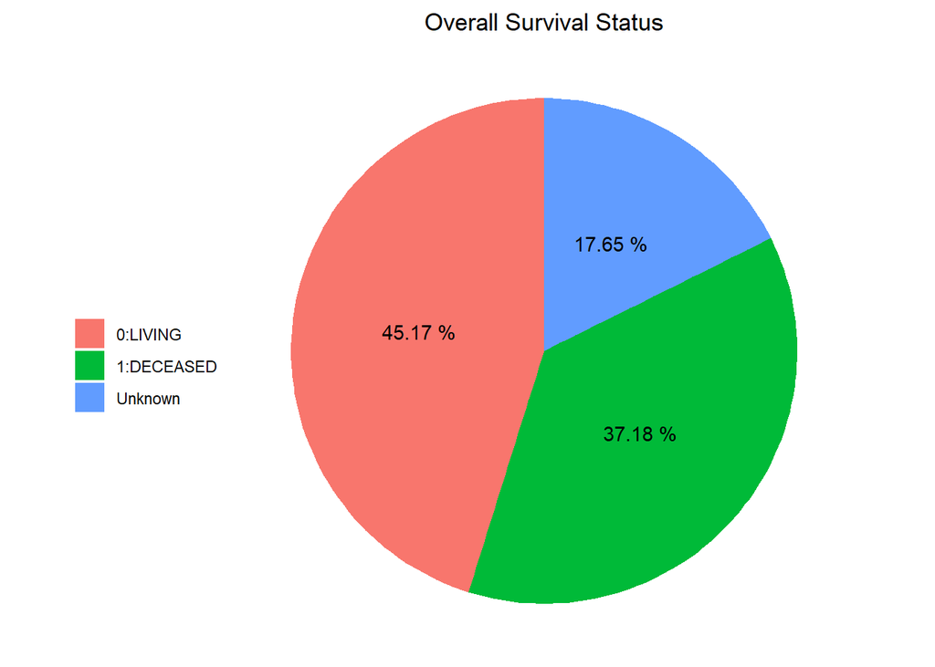

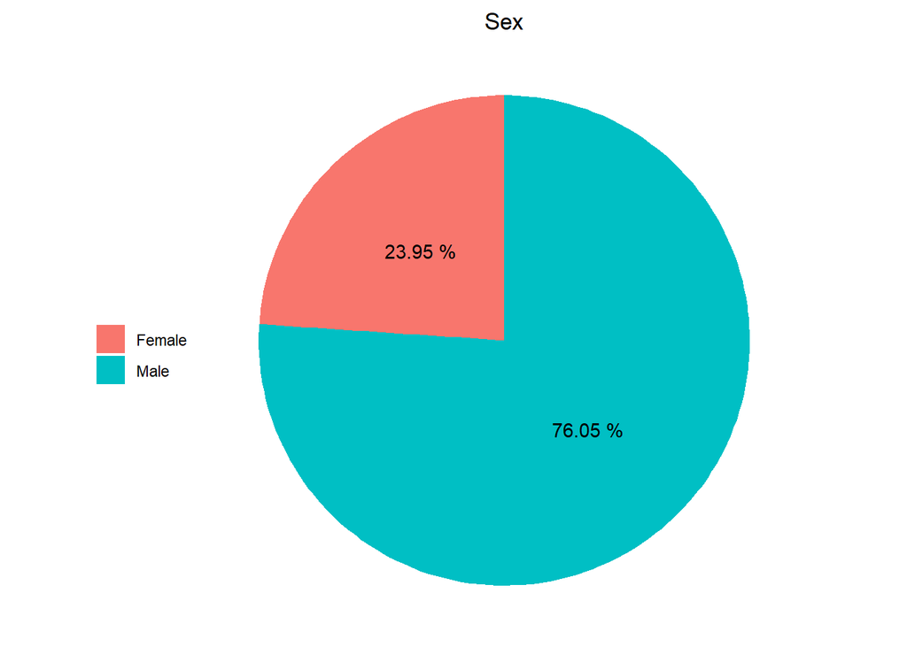

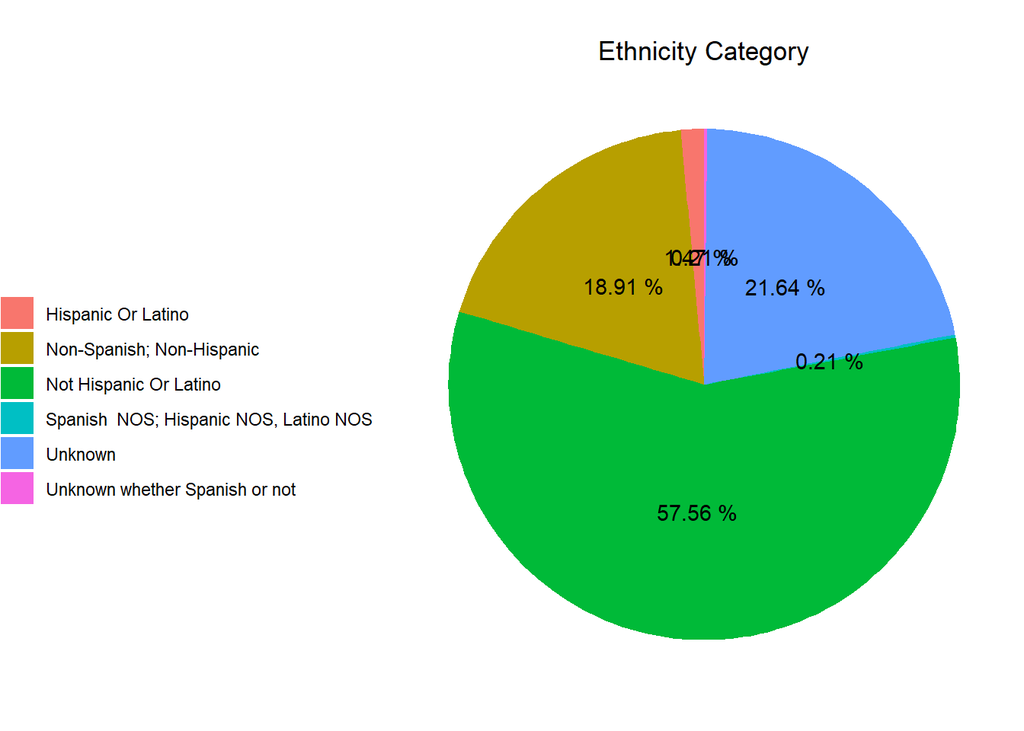

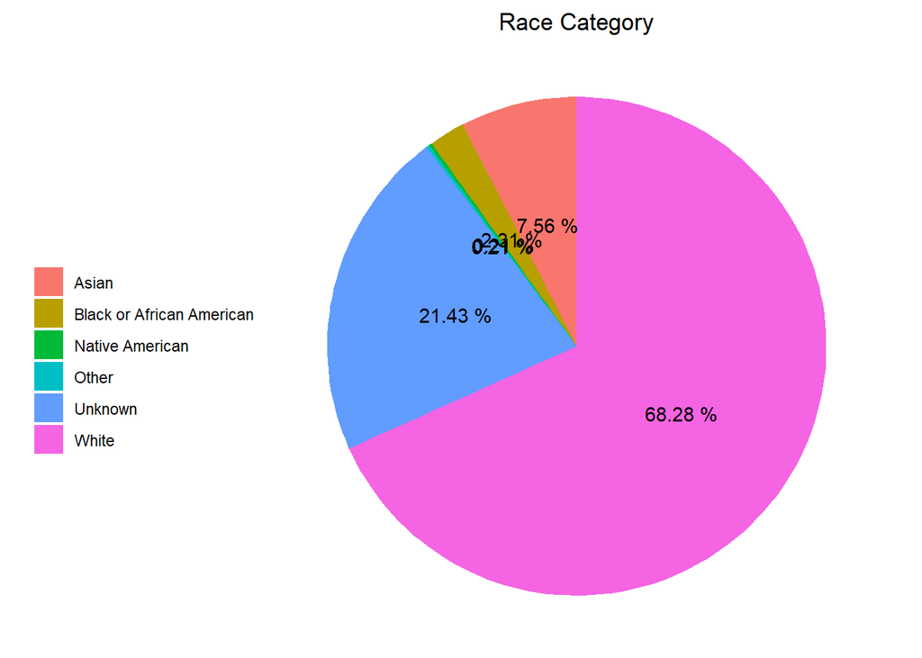

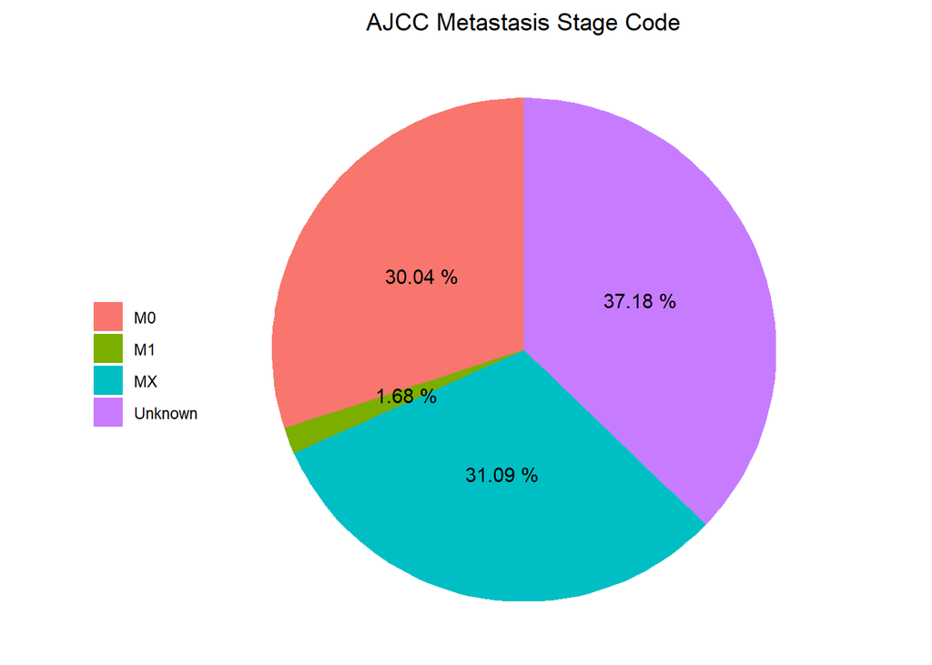

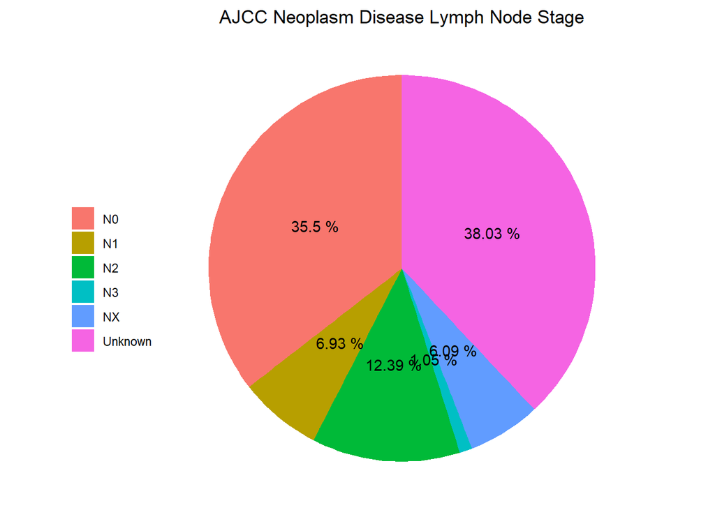

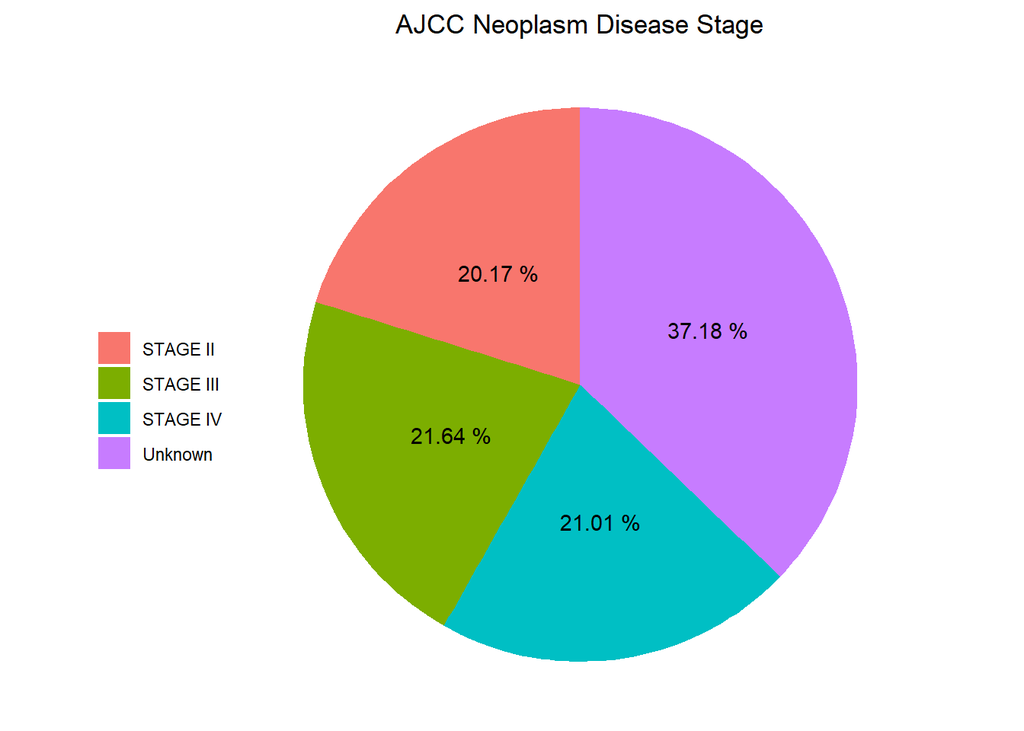

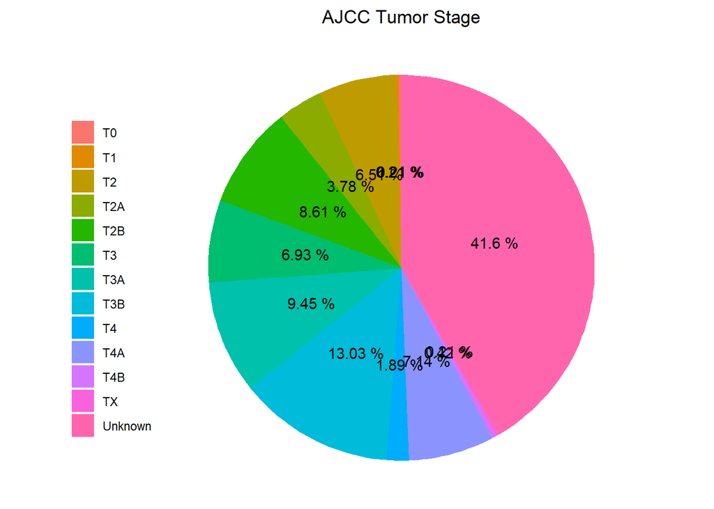

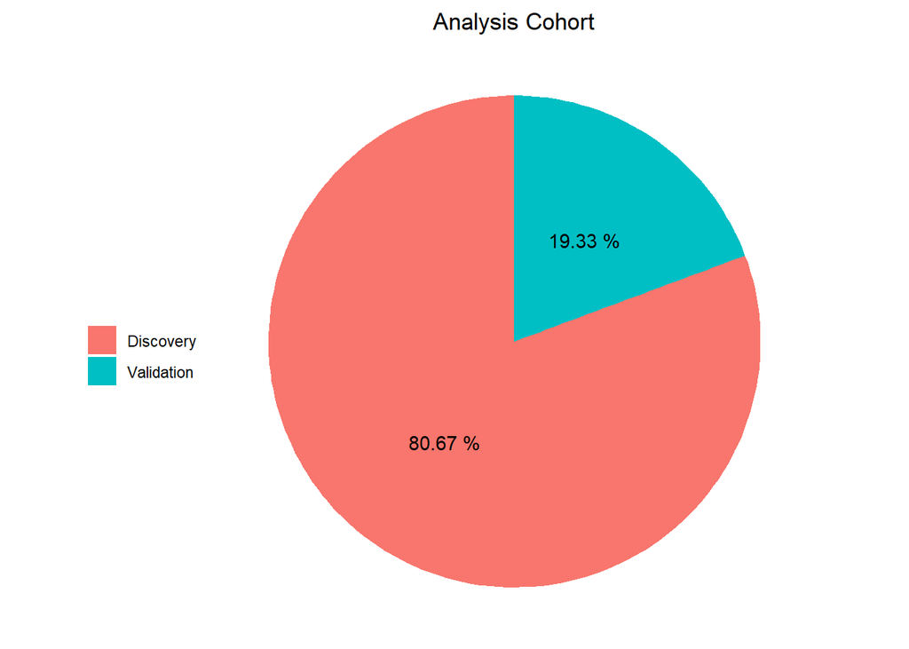

```r
### Pie Charts
## Código para fazer o plot pie chart de CADA UMA das colunas categóricas

# Definição dos títulos de cada piechart
plot_titles <- c(
  "Overall Survival Status",                # OS_STATUS
  "Sex",                                    # SEX
  "Ethnicity Category",                     # ETHNICITY
  "Race Category",                          # RACE
  "AJCC Metastasis Stage Code",             # PATH_M_STAGE
  "AJCC Neoplasm Disease Lymph Node Stage", # PATH_N_STAGE
  "AJCC Neoplasm Disease Stage",            # AJCC_PATHOLOGIC_TUMOR_STAGE
  "AJCC Tumor Stage",                       # PATH_T_STAGE
  "Analysis Cohort"                         # ANALYSIS_COHORT
)

# Definição das frequências e das frequências relativas
freq_list <- list(
  OS_STATUS = prop.table(table(bladder_clin$OS_STATUS)),
  SEX = prop.table(table(bladder_clin$SEX)),
  ETHNICITY = prop.table(table(bladder_clin$ETHNICITY)),
  RACE = prop.table(table(bladder_clin$RACE)),
  PATH_M_STAGE = prop.table(table(bladder_clin$PATH_M_STAGE)),
  PATH_N_STAGE = prop.table(table(bladder_clin$PATH_N_STAGE)),
  AJCC_PATHOLOGIC_TUMOR_STAGE = prop.table(table(bladder_clin$AJCC_PATHOLOGIC_TUMOR_STAGE)),
  PATH_T_STAGE = prop.table(table(bladder_clin$PATH_T_STAGE)),
  ANALYSIS_COHORT = prop.table(table(bladder_clin$ANALYSIS_COHORT))
)

# Criação de um dataframe com as frequências e os nomes das colunas
pie_data <- lapply(freq_list, function(freq_rel) {
  data.frame(labels = names(freq_rel), values = as.numeric(freq_rel))
})

# Criação dos pie charts
for (i in seq_along(plot_titles)) {
  plot_pies <- ggplot(pie_data[[i]], aes(x = "", y = values, fill = labels)) +
    geom_bar(stat = "identity", width = 1) +
    geom_text(aes(label = paste(round(freq_list[[i]] * 100, 2), "%")), position = position_stack(vjust = 0.5)) +
    coord_polar("y", start = 0) +
    labs(title = plot_titles[i], fill = "") +
    theme_void() +
    theme(
      legend.position = "left",
      plot.title = element_text(hjust = 0.5),
      plot.margin = margin(1)
    )

  print(plot_pies)
}
```

# Barplots (Gráficos de Barras)

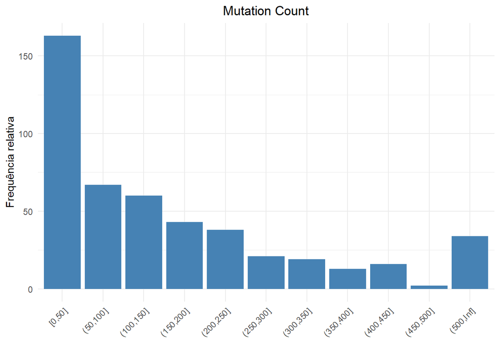

```r
# Função para criar os barplots através de iterações
create_barplot <- function(data, column_name, breaks, title) {
  table_data <- table(cut(data[[column_name]], breaks = breaks, include.lowest = TRUE))

  if (length(table_data) > length(breaks)) {
    table_data[length(table_data)] <- table_data[length(table_data)] + sum(data[[column_name]] > breaks[length(breaks)])
  }

  # Conversão para dataframe
  df <- data.frame(interval = names(table_data), count = as.numeric(table_data))
  df$interval <- factor(df$interval, levels = unique(df$interval))

  # Barplot geral
  plot_bar <- ggplot(df, aes(x = interval, y = count)) +
    geom_bar(stat = "identity", fill = "steelblue") +
    labs(title = title,
         x = "",
         y = "Frequência relativa") +
    theme_minimal() +
    theme(axis.text.x = element_text(angle = 45, hjust = 1),
          plot.title = element_text(hjust = 0.5))

  return(plot_bar)
}

create_barplot(bladder_clin, "MUTATION_COUNT", c(0, seq(50, 500, by = 50), Inf), "Mutation Count")
```

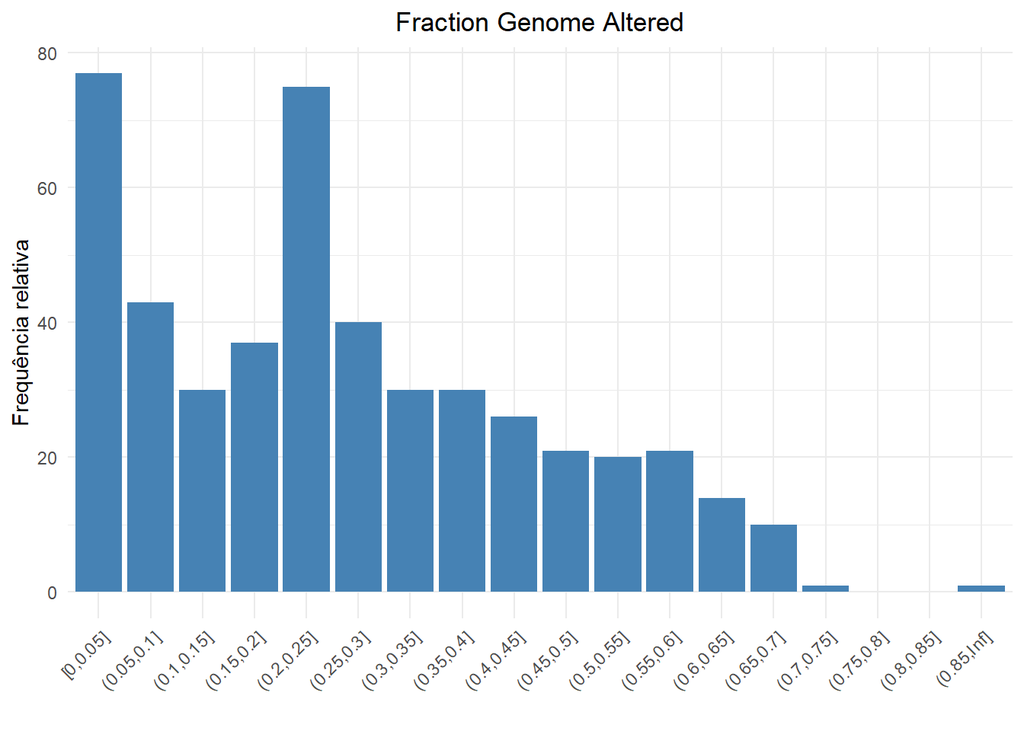

```r
create_barplot(bladder_clin, "FRACTION_GENOME_ALTERED", c(0, seq(0.05, 0.85, by = 0.05), Inf), "Fraction Genome Altered")
```

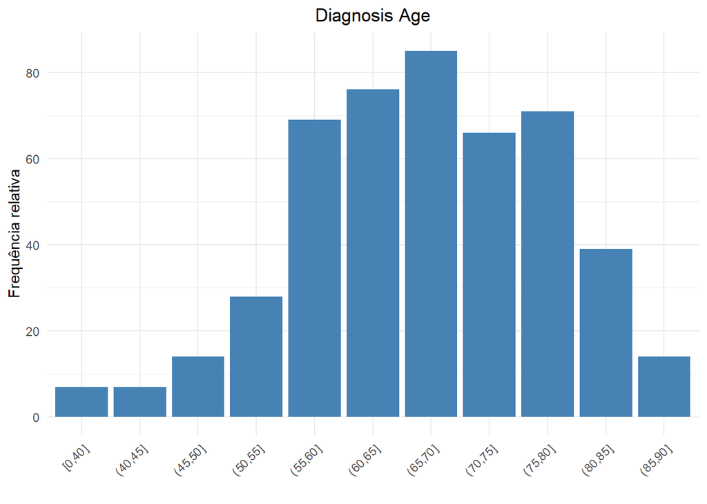

```r
create_barplot(bladder_clin, "AGE", unique(c(0, seq(40, max(bladder_clin$AGE), by = 5), max(bladder_clin$AGE))), "Diagnosis Age")
```

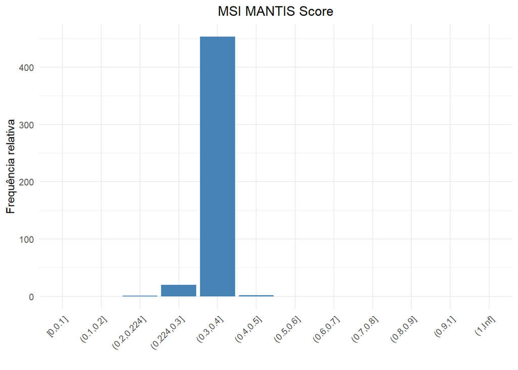

```r
create_barplot(bladder_clin, "MSI_SCORE_MANTIS", c(min(bladder_clin$MSI_SCORE_MANTIS), seq(0, 1, by = 0.1), Inf), "MSI MANTIS Score")
```

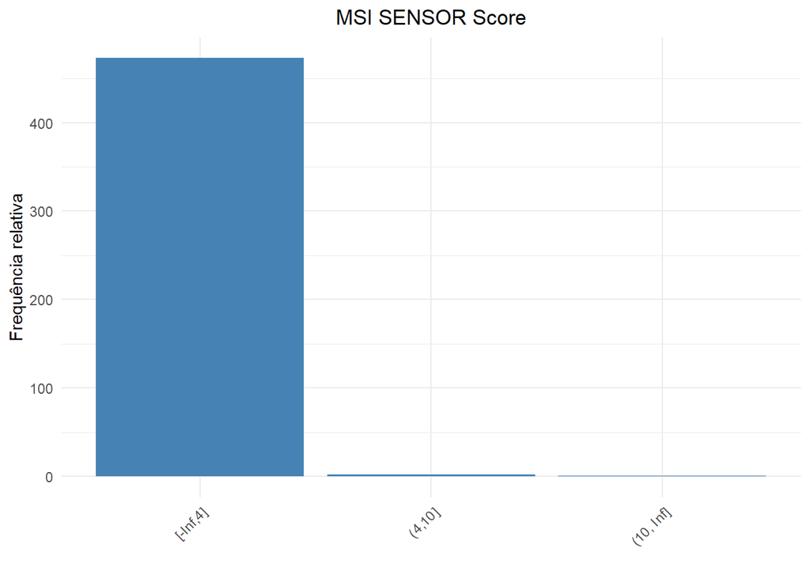

```r
create_barplot(bladder_clin, "MSI_SENSOR_SCORE", c(-Inf, 4, 10, Inf), "MSI SENSOR Score")
```

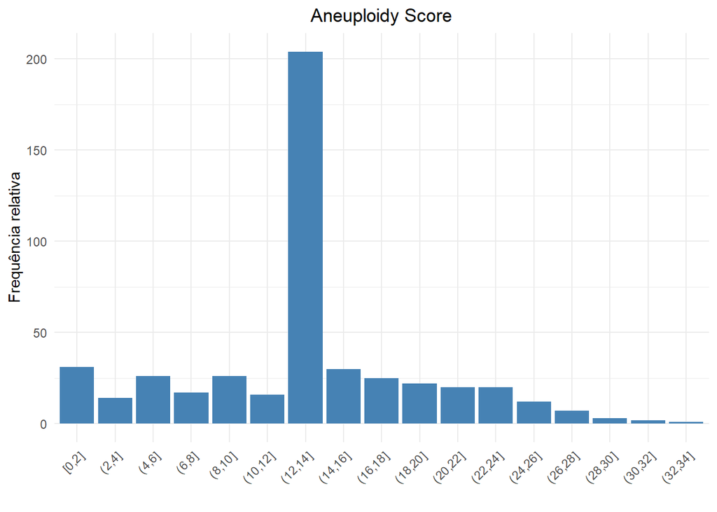

```r
create_barplot(bladder_clin, "ANEUPLOIDY_SCORE", c(seq(0, max(bladder_clin$ANEUPLOIDY_SCORE), by = 2)), "Aneuploidy Score")
```

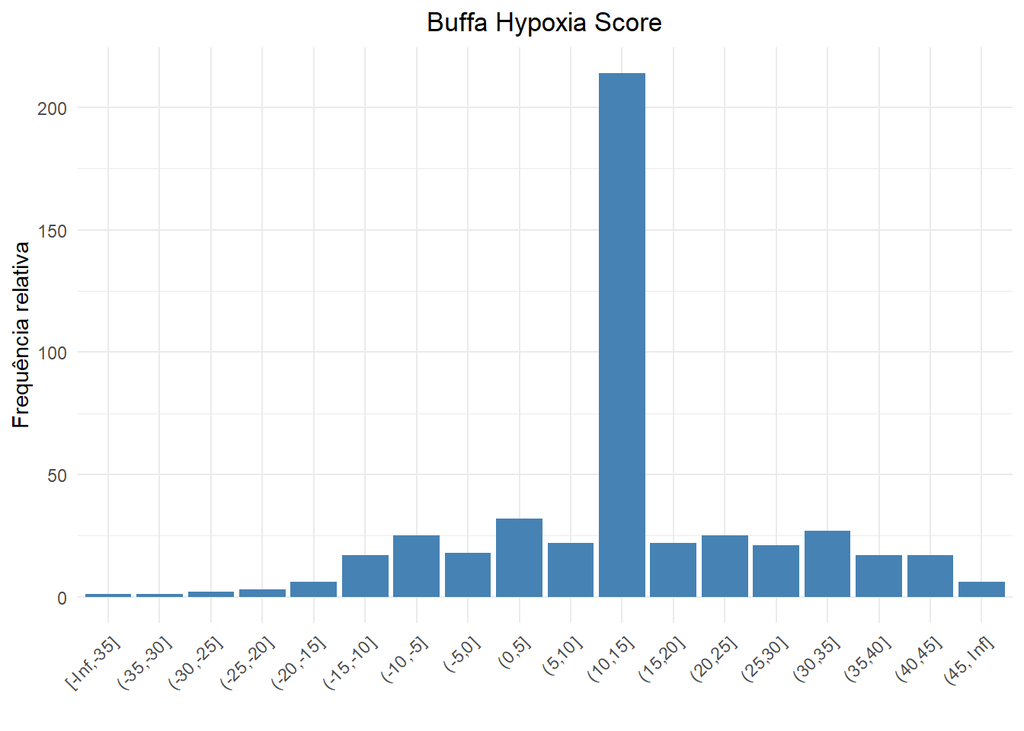

```r
create_barplot(bladder_clin, "BUFFA_HYPOXIA_SCORE", c(-Inf, seq(-35, 45, by = 5), Inf), "Buffa Hypoxia Score")
```

# Pairplots

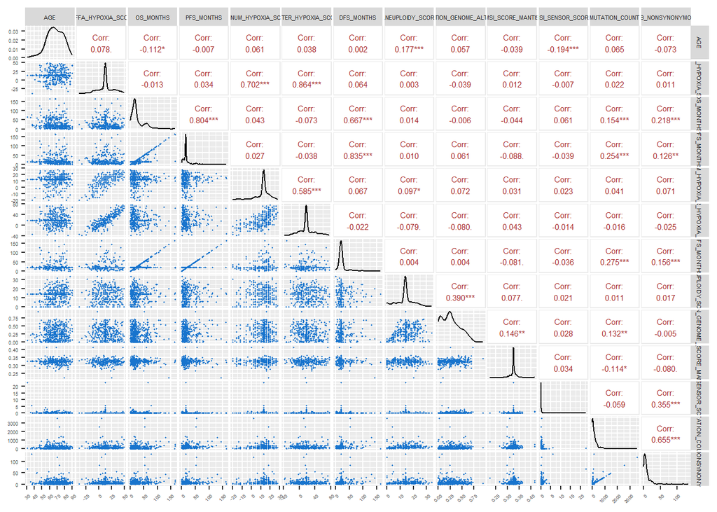

```r
### Aqui vamos observar os estados, distribuições e correlações dos nossos dados, incluindo entender o que podemos fazer para normalização dos dados. ###

# Pairplot PRE-NOMALIZAÇÃO para ver os gráficos das correlações possíveis entre colunas
# Subconjunto do conjunto de dados para apenas incluir as colunas numéricas
numeric_data <- bladder_clin[, sapply(bladder_clin, is.numeric)]

# Criação de um pairplot com só as colunas numéricas para verificar as correlações
pairplot1 <- GGally::ggpairs(numeric_data, cardinality_threshold = Inf,
                            upper = list(continuous = wrap("cor", size = 2, color = "brown")),
                            lower = list(continuous = wrap("points", size = 0.25, color = "dodgerblue3"))) +
  theme(text = element_text(size = 4),
        axis.text.x = element_text(angle = 45, hjust = 1),
        strip.text = element_text(size = 4),
        panel.spacing = unit(0.1, "lines")) # Ajusta espaços entre os gráficos/painéis

pairplot1 # Pairplot PRE-NORMALIZAÇÃO
```

```r
ggsave("pairplot1.png", pairplot1, width = 10, height = 6) # Guarda o pairplot como uma imagem .png no working directory. Os parâmetros "width" e "height" definem o tamanho dele, caso queiram ver o pairplot, ele está disponível na mesma pasta que este ficheiro .Rmd!
```

## Visualização geral da Normalização dos dados

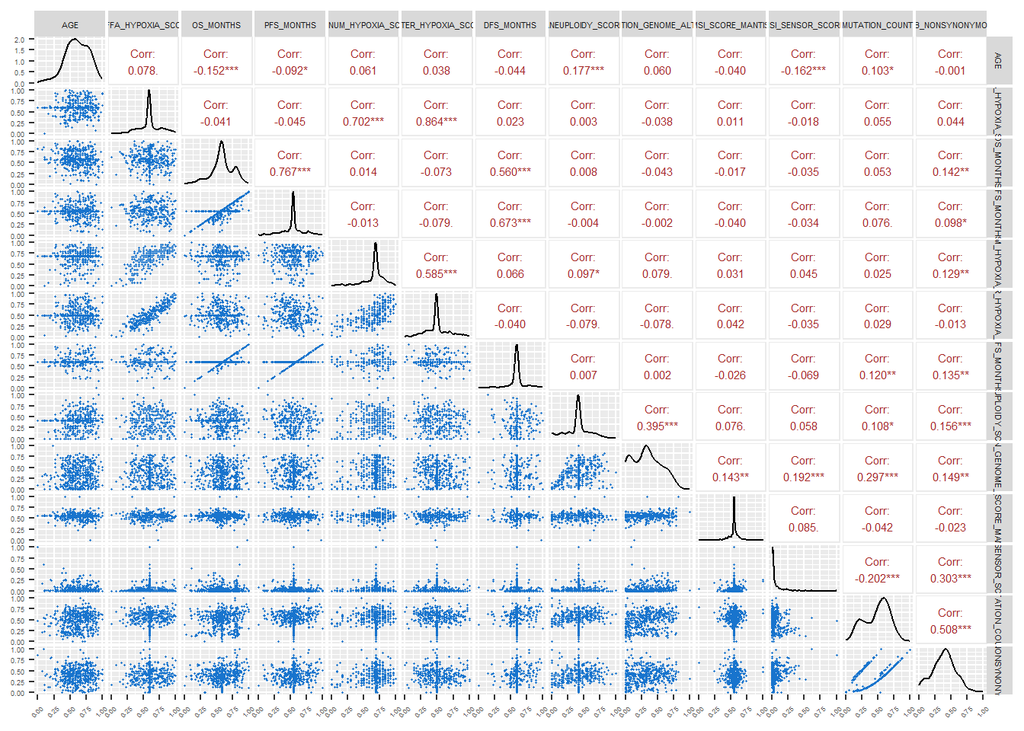

```r
# Vamos voltar a fazer o pairplot depois de termos feito a normalização dos dados...
# As colunas resultantes neste pairplot foram transformadas!

# Pairplot PÓS-NOMARLIZAÇÃO (repetição do código do pairplot1, mas definido como "pairplot2" para fazermos comparações)
numeric_data <- bladder_clin[, sapply(bladder_clin, is.numeric)]

pairplot2 <- GGally::ggpairs(numeric_data, cardinality_threshold = Inf,
                            upper = list(continuous = wrap("cor", size = 2, color = "brown")),
                            lower = list(continuous = wrap("points", size = 0.25, color = "dodgerblue3"))) +
  theme(text = element_text(size = 4),
        axis.text.x = element_text(angle = 45, hjust = 1),
        strip.text = element_text(size = 4),
        panel.spacing = unit(0.1, "lines"))

pairplot2 # Pairplot PÓS-NORMALIZAÇÃO
```

[output not shown]

```r
ggsave("pairplot2.png", pairplot2, width = 10, height = 6)
```

## Análise de Expressão Diferencial

Para este passo é necessário pesquisar e Baixar Dados de Expressão Genética do TCGA-ACC

```r
# # Ver que projetos estão disponíveis
# gdcprojects <- getGDCprojects()

# Define o projeto
project <- "TCGA-ACC"

# Sumário dos ficheiros presentes no projeto
getProjectSummary(project)
```

```
## $file_count
## [1] 5134
##
## $data_categories
##    file_count case_count                data_category
## 1        1594         92  Simple Nucleotide Variation
## 2         658         92             Sequencing Reads
## 3         517         92                  Biospecimen
## 4         197         92                     Clinical
## 5        1120         92        Copy Number Variation
## 6         318         80      Transcriptome Profiling
## 7         240         80              DNA Methylation
## 8          46         46           Proteome Profiling
## 9         128         64 Somatic Structural Variation
## 10        316         79         Structural Variation
##
## $case_count
## [1] 92
##
## $file_size
## [1] 3.997621e+13
```

```r
# Configura a consulta com o tipo de amostra correto
query <- GDCquery(project = project,
                  data.category = "Transcriptome Profiling",
                  data.type = "Gene Expression Quantification",
                  workflow.type = "STAR - Counts",
                  sample.type = "Primary Tumor")
```

```
## o GDCquery: Searching in GDC database
```

```
## Genome of reference: hg38
```

```
## oo Accessing GDC. This might take a while...
```

```
## ooo Project: TCGA-ACC
```

```
## oo Filtering results
```

```
## ooo By data.type
```

```
## ooo By workflow.type
```

```
## ooo By sample.type
```

```
## oo Checking data
```

```
## ooo Checking if there are duplicated cases
```

```
## ooo Checking if there are results for the query
```

```
## o Preparing output
```

```r
# # Ver que ficheiros temos no projeto
# output_query <- getResults(query)

# Baixa os dados
GDCdownload(query)
```

```
## Of the 79 files for download 79 already exist.
```

```
## All samples have been already downloaded
```

```r
# Prepara os dados para análise
data <- GDCprepare(query)
```

```
## Starting to add information to samples
```

```
##  => Add clinical information to samples
```

```
##  => Adding TCGA molecular information from marker papers
```

```
##  => Information will have prefix 'paper_'
```

```
## acc subtype information from:doi:10.1016/j.ccell.2016.04.002
```

```
## Available assays in SummarizedExperiment :
##   => unstranded
##   => stranded_first
##   => stranded_second
##   => tpm_unstrand
##   => fpkm_unstrand
##   => fpkm_uq_unstrand
```

```r
## Mencionando aqui caso haja problemas com o GDCdownload() e o GDCprepare(), se está a utilizar Windows, certifique-se que o 'working directory' deste trabalho encontra-se numa diretoria de tamanho INFERIOR A 60 CARACTERES! Isto porque o GDCdownload vai criar as pastas onde os ficheiros .tsv vão ficar, se a 'working directory' tiver mais de 60 caracteres, a diretoria resultante de CADA UM DESTES FICHEIROS vai ter mais de 260 caracteres de comprimento, excedendo o limite path/filename do Windows!!! Fonte: https://github.com/BioinformaticsFMRP/TCGAbiolinks/issues/153#issuecomment-1380580924
```

```r
# colData(data)
# rowData(data)
# names(assays(data))
```

```r
# Análise de Expressão Diferencial:

library(DESeq2)

# Usando o ensaio identificado como "unstranded"
dds <- DESeqDataSetFromMatrix(countData = assay(data, "unstranded"),
                              colData = colData(data),
                              design = ~ gender)  # Ou outra variável de interesse
dds <- DESeq(dds)
```

```
## -- replacing outliers and refitting for 4441 genes
## -- DESeq argument 'minReplicatesForReplace' = 7
## -- original counts are preserved in counts(dds)
```

```r
res <- results(dds)
summary(res)
```

```
##
## out of 52766 with nonzero total read count
## adjusted p-value < 0.1
## LFC > 0 (up)       : 607, 1.2%
## LFC < 0 (down)     : 776, 1.5%
## outliers [1]       : 0, 0%
## low counts [2]     : 23356, 44%
## (mean count < 1)
## [1] see 'cooksCutoff' argument of ?results
## [2] see 'independentFiltering' argument of ?results
```